# データ解析論I第8講

## 目次

## 前回の復習

## 一般線形モデルとは

## 概要

一般線形モデルとは，統計学の中でも，以下の数式（モデル式）を元に考えていくモデルです．

\[Y_i=\beta_1 X_1 +\beta_2 X_2+ \beta_3 X_3 + .... \alpha+\epsilon_i \]

さて，何か複雑そうなモデル式が出てきてしまいましたが，恐れることはありません．少し，簡単な形にしてあげましょう．そうすると，こんな感じに書くことが出来ます．

\[Y_i=\beta_1 X_1 + \alpha+\epsilon_i \]

このモデル式，何だか見覚えのあるグラフとそっくりだと思います．中学校の時に“一次関数”というのを教わったのを覚えていますでしょうか？一次関数ではこんな数式を使いました．

\[Y=\beta X + \alpha\]

この数式を元に，グラフを書く，ということもやったかと思います．この時，\(\beta\) を傾き，\(\alpha\) を切片という呼び方をしていました．ちなみに，この数式で直線のグラフを書く時には，Xに0を代入した時のポイント(0, \(\alpha\))とXに1を代入したときのポイント(1, \(\beta + \alpha\))を結ぶ直線を引いてあげれば，グラフを作成することができます．

一般線形モデルの一番理解しやすい最初の考え方は，「実際に観察されたデータを元にして，一次関数のような直線を引いてあげよう！」という発想です．ただし，一次関数とちょっと違うのは「全ての点を通らなくてよい」ということです．

## 誤差

一次関数の場合はその直線上にある全ての点を通ることが前提となっていました．しかし，実際には直線であるので，直線上の2点を通れば，全てその条件を満たす直線を引くことが出来ます．

しかし，一般線形モデルの場合は常に全ての点を通るとは限りません．ベストは全ての点を通ることではありますが，実際にはデータには「誤差」というものが存在します．これは本来得られるべき結果と実際に得られた結果にずれがあることを示しています．

この誤差には大きく分けて次の3種類あります．

## 3種類の誤差

- 測定誤差：実際に何かを計測する時に生じる誤差．中でも以下の2種類がある．
  - 系統誤差（システマティック）：何らかの要因により，常に生じてしまう誤差．例えば，自動車で運転者が40km/hで走っているつもりであっても，外部から正確なスピードメーターによって調べると38km/hしか出ていない，など．これはメーターが原因で生じる系統（システマティック）誤差である．
  - 偶然誤差：何らかの要因により，偶然生じてしまう誤差．例えば，ブレーキをかけたときに60mで普段止まるが，偶然入ったホコリや水分などによって70mで止まってしまうかもしれない．これは偶然入ったホコリや水分による偶然誤差である．
- 計算誤差：数値をどこかで四捨五入したことによって生じる誤差．例えば，1/3を0.333にして計算することによって計算誤差が生じる．
- 統計誤差（標準誤差）：母集団からある一部の集団を取り出す時，選ぶ集団によってどの程度数値が異なり得るのかを調べたもの．統計的に異なり得る範囲を推測することができる，

## 本題に戻って

さて，少し本題に戻りましょう．ちょっと一般線形モデルのモデル式を考えたいと思います．

\[Y_i=\beta_1 X_1 + \alpha+\epsilon_i \]

改めて，このモデル式を説明したいと思います．ここで，“\(Y_i\)”のことを“応答変数”，“\(X_1\)”のことを“説明変数”と呼びましょう．

文字についている“\(_i\)”は各データによって異なる！という区別をするためについています．ちなみに，“\(Y_i\)”は他にも，被説明変数と呼ばれたりします．

また，"\(\beta_1\)" は係数，“\(\alpha\)” は切片と呼ばれます．そして，“\(\epsilon_i\)”が一番問題となる誤差です．この誤差は予測されたモデル式である“\(Y_i=\beta_1 X_1 + \alpha\)”からどれだけそのデータの値が離れているかを示しています．

と，言ってもなかなか理解し難いと思うので，一つ試しにやってみましょう．ここでは，「回帰分析」という方法と「t検定」という方法についてお話をしたいと思います．

| 検定名 | 応答変数 | 説明変数 |
| --- | --- | --- |
| 回帰分析 | 数値データ | 数値データ(順序データ) |
| t検定 | 数値データ | 因子データ(ダミー変数,1, 0) |

## 回帰分析

## 回帰分析とは

回帰分析とは，応答変数が数値データであり，説明変数も数値データである場合に用いる方法です．例えば，「身長」と「体重」の間の相関関係について分析をする際にも用います．ここでは，今まで授業で使ってきた「主観的幸福度」と「生活満足度」の間に相関関係があるかどうか，以下の順番に沿って考えてみましょう．

この関係はモデル式で表すと，このような形になります．

\[(主観的幸福度)=\beta_1 (生活満足度) + \alpha+\epsilon_i \]

この時，切片であるは生活満足度が0であった時に対応する主観的幸福度を示しています．

## 仮説を立てる

何はともあれ，統計分析をするときには仮説を立ててあげる必要があります．仮説を立てるときには，「帰無仮説」と「対立仮説」の2つを考える必要があります． 対立仮説は「イイタイコト」，帰無仮説は「イイタイコトではないこと」でした．

ここで主観的幸福度と生活満足度の関係ですので，以下のように設定できます．

- 対立仮説：生活満足度が変化するにつれて，主観的幸福度も変化する．
- 帰無仮説：生活満足度が変化するにつれて，主観的幸福度も変化するとはいえない．

特に，以下では応答変数を主観的幸福度，説明変数を生活満足度とします．

## 散布図をプロットする

はじめに，分析対象となるデータを読み込んでおきましょう． * もちろん，既に読み込んである場合は飛ばしてもらって構いません．

散布図のプロットは他の機能から持ってきてもよいのですが，今回はRStudio上でクリックだけで入れられる方法を紹介します．

その上で，コードを貼り付けて出力することにしましょう．

- 以前紹介した“esquisse”を使います．動画をご確認ください．

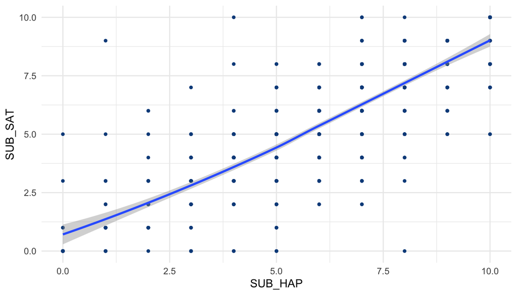

```r
library(ggplot2)

ggplot(exdataset) +
 aes(x = SUB_HAP, y = SUB_SAT) + geom_point(size = 1L, colour = "#0c4c8a") +
 geom_smooth(span = 1L) + theme_minimal()
```

どうもグラフを見ている限りだと，この2変数間には正の相関関係，すなわち「生活満足度が高ければ高いほど，主観的幸福度が高くなる」という傾向にはありそうです．

ただし，今はグラフを見ているだけなので，果たしてこの傾向が本当にあるのかどうかがわかりません．今度はこの傾向が科学的に認められるのかどうかを考えてみましょう．

## 回帰分析をやってみる．

さて，今度はRで分析してみましょう．ここでは，2行ほどのコードを書いてもらいます．

```r
hapsat_model<-lm(SUB_HAP~SUB_SAT, data = exdataset)
summary(hapsat_model)
```

```
##
## Call:
## lm(formula = SUB_HAP ~ SUB_SAT, data = exdataset)
##
## Residuals:
##     Min      1Q  Median      3Q     Max
## -7.8918 -0.6503 -0.0814  0.7289  6.4015
##
## Coefficients:
##             Estimate Std. Error t value Pr(>|t|)
## (Intercept)  1.59853    0.10176   15.71   <2e-16 ***
## SUB_SAT      0.81036    0.01711   47.37   <2e-16 ***
## ---
## Signif. codes:  0 '***' 0.001 '**' 0.01 '*' 0.05 '.' 0.1 ' ' 1
##
## Residual standard error: 1.285 on 961 degrees of freedom
## Multiple R-squared:  0.7002, Adjusted R-squared:  0.6999
## F-statistic:  2244 on 1 and 961 DF,  p-value: < 2.2e-16
```

## 出力結果について説明しましょう．

```
## Call:
## lm(formula = SUB_HAP ~ SUB_SAT, data = exdataset)
```

この行では，分析したモデル式について示しています．簡単に言うと，「生活満足度によって，主観的幸福度は説明できるかどうか試してます．．．」ということを示しています．

```
## Residuals:
##     Min      1Q  Median      3Q     Max
## -7.8918 -0.6503 -0.0814  0.7289  6.4015
```

ここでは，モデル式からのズレ(\(\epsilon_i\))である誤差がどの程度あるのかを示しています．ここでは誤差の最小値，第1四分位点，中央値，第3四分位点，最大値を示しています．一般線形モデルではこの誤差が正規分布になっていることを仮定しています．

```
## Coefficients:
##             Estimate Std. Error t value Pr(>|t|)
## (Intercept)  1.59853    0.10176   15.71   <2e-16 ***
## SUB_SAT      0.81036    0.01711   47.37   <2e-16 ***
## ---
## Signif. codes:  0 '***' 0.001 '**' 0.01 '*' 0.05 '.' 0.1 ' ' 1
```

- ここではその分析結果について示しています．第一に注目すべきはこの項目です．
- “Intercept”は切片を示しています．先程のモデル式でいうと，\(\alpha\) にあたる部分です．
- 加えて，“SUB_SAT”は生活満足度です．先程のモデル式でいうと，\(\beta_1\)にあたる部分です．“Estimate”は推定値を示しています．“Intercept”と交わるところでは\(\alpha\)に入る具体的な数字を示しています．また，“SUB_SAT”と交わるところでは\(\beta_1\)に当てはまる数字が入ります．

したがって，この結果はモデル式で書くと，以下のように示すことが出来ます．

\[(主観的幸福度)=0.81036 ×(生活満足度) + 1.59853+\epsilon_i \]

このモデル式は生活満足度が1あがると，主観的幸福度が0.8106ポイント増加すること，そして生活満足度が0である人の主観的幸福度は1.59853であることが推定されています．

ここに出てくるt valueはt値を，Pr(>|t|)はp値を示しています．そして，最後のsign.if. codesでは，どのような基準で*をつけているかを説明しています．この場合，p値が1-0.1の場合は無印，0.1-0.05の場合は“.”，0.05-0.01の場合は“*”，0.01-0.001の場合は“**”，0.001-0の場合は“***”，としてつけている，ということが示されています．

統計学の基本的な考え方ではp値が0.05以下，すなわち5%以下である場合には対立仮説を採択することがお約束となっています．．．が，単純に5%以下であることによって対立仮説を採択することがあってはいけません．

それは以下の理由によります．

- 分野によって10%以上でも有意差を認めることがある．
- 統計的な有意性はデータの量にも依拠するため，単純に評価してよいかどうかは課題がある．
  - 心理学系だと「効果量」という議論がある．

```
## Multiple R-squared:  0.7002, Adjusted R-squared:  0.6999
## F-statistic:  2244 on 1 and 961 DF,  p-value: < 2.2e-16
```

続いて，確認したいのはこの2行です．“Multiple R-squared”はR2乗(あーるにじょう)値を示しています．ただし，このR2値は決定係数と呼ばれており，回帰式の当てはまり具合を示しています．寄与率とも呼ばれて，この値が1に近ければ近いほどよく説明できているモデル式であると言われます．ただし，R2乗値はこのモデルに組み込まれる説明変数が増えれば増えるほど，より良くなっていきます．そうするといくらでも興味のない変数を入れて重回帰分析（後日説明します）．．．．と，なると決して意味があるモデル式になるとは言えません．

そこで，たくさん変数を入れたことに対するペナルティを加えたのが“Adjusted R-squared”，調整済みR2乗値と呼ばれるものです．こちらを報告してあげると良いかと思います．

結果の表記例．

## 結果をきれいに表記しよう．

- パッケージpanderの中にある関数panderを使うと，結果がわかりやすく表示されます．

```r
library(pander)
pander(hapsat_model)
```

Fitting linear model: SUB_HAP ~ SUB_SAT

|  | Estimate | Std. Error | t value | Pr(>\|t\|) |
| --- | --- | --- | --- | --- |
| **(Intercept)** | 1.599 | 0.1018 | 15.71 | 1.156e-49 |
| **SUB_SAT** | 0.8104 | 0.01711 | 47.37 | 1.337e-253 |

- 私のはCSSをいじっているので少し色が変わっています．
- 他にもパッケージhuxtableの中にhuxregという関数があります．

```r
library(huxtable)
huxreg(hapsat_model)
```

|  | (1) |
| --- | --- |
| (Intercept) | 1.599 *** |
|  | (0.102) |
| SUB_SAT | 0.810 *** |
|  | (0.017) |
| N | 963 |
| R2 | 0.700 |
| logLik | -1607.061 |
| AIC | 3220.121 |
| *** p < 0.001; ** p < 0.01; * p < 0.05. |  |

- パッケージstargazerの中にあるstargazerという関数を使うとxls形式で出力できます．

```r
library(stargazer)
stargazer(hapsat_model, type = "html", align=TRUE,
          title = "分析結果", out = "hapsatmodel.xls")
```

[output not shown]

- 作業フォルダの中に“hapsatmodel.xls”というファイルができていますので，そちらを開いてください．
  - 開く際に注意画面が出てきますが，「気にせずに開く」を選んでください．

## t値とは？

\[t値=(期待値)-(平均値)/(標準誤差)\]

t値はこんな数式から算出されます．

標準誤差は(標準偏差)/(データ数の平方根)によって計算できることを思い出しておいて下さい． t値は分子が大きければ，平均値との差が大きいことを示しており，分母が大きければ，標準偏差（分散）が小さく，データ数が十分にあることを示しています．このt値が大きければ大きいほど，帰無仮説を棄却して対立仮説を採択できることを示しています．

一方，p値は帰無仮説が成立していることを前提として，0.05，すなわち5%未満であれば，帰無仮説を棄却するための基準となります．実際に確率的に示すことによって，得られた差異がどの程度珍しいのか，ということを示しています．例えば，p値が0.03，すなわち3%であれば，帰無仮説が正しいとした時に今得られた結果は3%でしか観察できないような珍しいことが起こっていることを示しています．こんなに珍しいことが起こったのは，その帰無仮説が正しくないからであり対立仮説を選ぼう！という論理のもとに対立仮説を採択することになります．

ここでは，t値とp値の計算方法については別書に譲ることとして，ざっくりとした理解で先に行きましょう．

## 回帰分析

- 回帰分析：
  - \[Y_i=\beta_1 X_1 + \alpha+\epsilon_i \]
  - をモデル式として，“\(Y_i\)”および“\(X_i\)”のいずれもが数値データの場合に用いる．
    - 対立仮説：“説明変数”が変化すると，“応答変数”も変化する
    - 帰無仮説：“説明変数”が変化すると，“応答変数”も変化するとはいえない．
  - Rの関数では以下の形式を用いる．

```
# モデルを作る
オブジェクト <- lm(応答変数 ~ 説明変数, data = データセットの名前)

# 結果を出力する
summary(オブジェクト)
```

## 今日のやること：

## 今までの復習と演習問題

- 今日は今までの復習を中心とします．
- 今までがっつり詰めてやってきたので，ちょっと息抜きがてら復習の時間とします．

## 問題

### いずれもRないしはjamoviでやってみましょう．

- 苦手な人はjamoviで，得意な人はRでやってみましょう．
- どちらでやったからといって成績上不利益を被ることはありません．

## 問題1

### “exdataset”の中にある“ARE”は居住地域を，“MAR”は結婚しているか否かを尋ねているものである．これについて，以下の課題を実施してください．

1. “ARE”についてヒストグラム（度数分布がわかるグラフ）を作成してください．
2. “MAR”についてヒストグラム（度数分布がわかるグラフ）を作成してください．
3. “ARE”と“MAR”についてクロス表を作成し，\(\chi^2\)検定を行ってください．
- 残差分析はいりませんが，できそうならば試してください．

## 問題2

### “exdataset”の中にあるSUB_SLP"は睡眠満足度を10点満点で尋ねたものである．これについて，以下の課題を実施してください．

1. 睡眠満足度を応答変数，第二者被監視感“KAN_SEC”を説明変数とした回帰分析を行ってください．
2. 睡眠満足度を応答変数，第三者被監視感“KAN_THI”を説明変数とした回帰分析を行ってください．
3. 睡眠満足度を応答変数，超自然的被監視感“KAN_SUP”を説明変数とした回帰分析を行ってください．

いずれも回帰分析の前に適切な図表を作成してください．

## 問題3

### 過去の授業について，わからないところがあれば各自で調べて確認しておいてください．